# DATA SCIENCE INTERVIEW PROJECT

### Portfolio Website https://samueltheanalyst.com.ng/

### Github Profile https://github.com/sammy3755

### Whatsapp Link https://api.whatsapp.com/message/2SO6SL7XMSALL1?autoload=1&app_absent=0

### Contact : +2348105278892

### Email okohsamuel99@gmail.com

## OVERALL TASK

In this project, you'll work with a dataset of homes for sale in Brazil. Your goal is to determine if there are regional differences in the real estate market. Also, you will look at southern Brazil to see if there is a relationship between home size and price.

#### Task 1: DATA CLEANING of `brasil-real-estate-1.csv` raw data.

Task 1.1: Import the CSV file into the DataFrame `df1`.

```python
# Importing necessary libraries
import pandas as pd
```

```python
# Reading the dataset
df1 = pd.read_csv(r"C:\Users\USER\Downloads\GSRA DS Interview project\GSRA DS project\brasil-real-estate-1.csv")
```

Task 1.2: Before you move to the next task, take a moment to inspect df1 using the info and head methods. What issues do you see in the data? What cleaning will you need to do before you can conduct your analysis?

```python
df1.head()
```

|  | property_type | place_with_parent_names | region | lat-lon | area_m2 | price_usd |
| --- | --- | --- | --- | --- | --- | --- |
| 0 | apartment | \|Brasil\|Alagoas\|Maceió\| | Northeast | -9.6443051,-35.7088142 | 110.0 | $187,230.85 |
| 1 | apartment | \|Brasil\|Alagoas\|Maceió\| | Northeast | -9.6430934,-35.70484 | 65.0 | $81,133.37 |
| 2 | house | \|Brasil\|Alagoas\|Maceió\| | Northeast | -9.6227033,-35.7297953 | 211.0 | $154,465.45 |
| 3 | apartment | \|Brasil\|Alagoas\|Maceió\| | Northeast | -9.622837,-35.719556 | 99.0 | $146,013.20 |
| 4 | apartment | \|Brasil\|Alagoas\|Maceió\| | Northeast | -9.654955,-35.700227 | 55.0 | $101,416.71 |

```python
# Setting the index to start from 1
df1.index = df1.index + 1
```

```python
# Printing the DataFrame to verify the change
df1.head(15)
```

|  | property_type | place_with_parent_names | region | lat-lon | area_m2 | price_usd |
| --- | --- | --- | --- | --- | --- | --- |
| 1 | apartment | \|Brasil\|Alagoas\|Maceió\| | Northeast | -9.6443051,-35.7088142 | 110.0 | $187,230.85 |
| 2 | apartment | \|Brasil\|Alagoas\|Maceió\| | Northeast | -9.6430934,-35.70484 | 65.0 | $81,133.37 |
| 3 | house | \|Brasil\|Alagoas\|Maceió\| | Northeast | -9.6227033,-35.7297953 | 211.0 | $154,465.45 |
| 4 | apartment | \|Brasil\|Alagoas\|Maceió\| | Northeast | -9.622837,-35.719556 | 99.0 | $146,013.20 |
| 5 | apartment | \|Brasil\|Alagoas\|Maceió\| | Northeast | -9.654955,-35.700227 | 55.0 | $101,416.71 |
| 6 | apartment | \|Brasil\|Alagoas\|Maceió\| | Northeast | -9.614414,-35.735621 | 56.0 | $75,727.07 |
| 7 | apartment | \|Brasil\|Alagoas\|Maceió\| | Northeast | -9.584755,-35.662909 | 68.0 | $110,916.18 |
| 8 | apartment | \|Brasil\|Alagoas\|Maceió\| | Northeast | -9.658285,-35.703827 | 187.0 | $249,641.14 |
| 9 | apartment | \|Brasil\|Alagoas\|Maceió\| | Northeast | NaN | 65.0 | $100,792.61 |
| 10 | apartment | \|Brasil\|Alagoas\|Maceió\| | Northeast | -9.66082,-35.702976 | 90.0 | $115,459.02 |
| 11 | apartment | \|Brasil\|Alagoas\|Maceió\| | Northeast | -9.6637998,-35.7115455 | 137.0 | $361,979.65 |
| 12 | apartment | \|Brasil\|Alagoas\|Maceió\| | Northeast | -9.661504,-35.702961 | 101.0 | $131,061.59 |
| 13 | house | \|Brasil\|Alagoas\|Marechal Deodoro\| | Northeast | -9.697809,-35.893414 | 140.0 | $99,856.45 |
| 14 | apartment | \|Brasil\|Alagoas\|Maceió\| | Northeast | -9.629426,-35.69973 | 250.0 | $466,625.47 |
| 15 | apartment | \|Brasil\|Alagoas\|Maceió\| | Northeast | NaN | 182.0 | $312,051.42 |

```python
# Checking the data types and missing values
df1.info()
```

```
<class 'pandas.core.frame.DataFrame'>
RangeIndex: 12834 entries, 1 to 12834
Data columns (total 6 columns):
 #   Column                   Non-Null Count  Dtype
---  ------                   --------------  -----
 0   property_type            12834 non-null  object
 1   place_with_parent_names  12834 non-null  object
 2   region                   12834 non-null  object
 3   lat-lon                  11551 non-null  object
 4   area_m2                  12834 non-null  float64
 5   price_usd                12834 non-null  object
dtypes: float64(1), object(5)
memory usage: 601.7+ KB
```

```python
# Print the count of NaN values in each column
print(df1.isnull().sum())
```

```
property_type                 0
place_with_parent_names       0
region                        0
lat-lon                    1283
area_m2                       0
price_usd                     0
dtype: int64
```

## Observation

#### From my observation in the exploratory analysis, the lat-lon column have about 1283 missing values,

#### also, lat and lon column is suppose to have seperate columns for better data exploration

## Solution

#### It would be ideal to drop rows with missing values since we cant assume lat-lon location using backward or roreward fill

```python
# Drop rows with missing values
df1 = df1.dropna()
```

```python
df1
```

|  | property_type | place_with_parent_names | region | lat-lon | area_m2 | price_usd |
| --- | --- | --- | --- | --- | --- | --- |
| 1 | apartment | \|Brasil\|Alagoas\|Maceió\| | Northeast | -9.6443051,-35.7088142 | 110.0 | $187,230.85 |
| 2 | apartment | \|Brasil\|Alagoas\|Maceió\| | Northeast | -9.6430934,-35.70484 | 65.0 | $81,133.37 |
| 3 | house | \|Brasil\|Alagoas\|Maceió\| | Northeast | -9.6227033,-35.7297953 | 211.0 | $154,465.45 |
| 4 | apartment | \|Brasil\|Alagoas\|Maceió\| | Northeast | -9.622837,-35.719556 | 99.0 | $146,013.20 |
| 5 | apartment | \|Brasil\|Alagoas\|Maceió\| | Northeast | -9.654955,-35.700227 | 55.0 | $101,416.71 |
| ... | ... | ... | ... | ... | ... | ... |
| 12829 | apartment | \|Brasil\|Pernambuco\|Recife\| | Northeast | -8.044497,-34.909519 | 74.0 | $134,182.11 |
| 12830 | apartment | \|Brasil\|Pernambuco\|Recife\| | Northeast | -8.056418,-34.909309 | 91.0 | $174,748.79 |
| 12831 | apartment | \|Brasil\|Pernambuco\|Recife\| | Northeast | -8.1373477,-34.909181 | 115.0 | $115,459.02 |
| 12832 | apartment | \|Brasil\|Pernambuco\|Recife\|Boa Viagem\| | Northeast | -8.1136717,-34.896252 | 76.0 | $137,302.62 |
| 12834 | apartment | \|Brasil\|Pernambuco\|Recife\|Boa Viagem\| | Northeast | -8.0578381,-34.882897 | 99.0 | $168,507.77 |

11551 rows × 6 columns

```python
# Print the count of NaN values in each column
print(df1.isnull().sum())
```

```
property_type              0
place_with_parent_names    0
region                     0
lat-lon                    0
area_m2                    0
price_usd                  0
dtype: int64
```

```python
## No more NaN values
```

Task 1.3: Use the `"lat-lon"` column to create two separate columns in `df1`: `"lat"` and `"lon"`. Make sure that the data type for these new columns is `float`.

```python
# Extract latitude and longitude from the "lat-lon" column using comma seperated values
df1[['lat', 'lon']] = df1['lat-lon'].str.split(',', expand=True)

# Convert the data type of "lat" and "lon" columns to float
df1['lat'] = pd.to_numeric(df1['lat'], errors='coerce').astype(float)
df1['lon'] = pd.to_numeric(df1['lon'], errors='coerce').astype(float)
```

```python
# Print the DataFrame to verify the changes
df1
```

|  | property_type | place_with_parent_names | region | lat-lon | area_m2 | price_usd | lat | lon |
| --- | --- | --- | --- | --- | --- | --- | --- | --- |
| 1 | apartment | \|Brasil\|Alagoas\|Maceió\| | Northeast | -9.6443051,-35.7088142 | 110.0 | $187,230.85 | -9.644305 | -35.708814 |
| 2 | apartment | \|Brasil\|Alagoas\|Maceió\| | Northeast | -9.6430934,-35.70484 | 65.0 | $81,133.37 | -9.643093 | -35.704840 |
| 3 | house | \|Brasil\|Alagoas\|Maceió\| | Northeast | -9.6227033,-35.7297953 | 211.0 | $154,465.45 | -9.622703 | -35.729795 |
| 4 | apartment | \|Brasil\|Alagoas\|Maceió\| | Northeast | -9.622837,-35.719556 | 99.0 | $146,013.20 | -9.622837 | -35.719556 |
| 5 | apartment | \|Brasil\|Alagoas\|Maceió\| | Northeast | -9.654955,-35.700227 | 55.0 | $101,416.71 | -9.654955 | -35.700227 |
| ... | ... | ... | ... | ... | ... | ... | ... | ... |
| 12829 | apartment | \|Brasil\|Pernambuco\|Recife\| | Northeast | -8.044497,-34.909519 | 74.0 | $134,182.11 | -8.044497 | -34.909519 |
| 12830 | apartment | \|Brasil\|Pernambuco\|Recife\| | Northeast | -8.056418,-34.909309 | 91.0 | $174,748.79 | -8.056418 | -34.909309 |
| 12831 | apartment | \|Brasil\|Pernambuco\|Recife\| | Northeast | -8.1373477,-34.909181 | 115.0 | $115,459.02 | -8.137348 | -34.909181 |
| 12832 | apartment | \|Brasil\|Pernambuco\|Recife\|Boa Viagem\| | Northeast | -8.1136717,-34.896252 | 76.0 | $137,302.62 | -8.113672 | -34.896252 |
| 12834 | apartment | \|Brasil\|Pernambuco\|Recife\|Boa Viagem\| | Northeast | -8.0578381,-34.882897 | 99.0 | $168,507.77 | -8.057838 | -34.882897 |

11551 rows × 8 columns

Task 1.4: Use the `"place_with_parent_names"` column to create a `"state"` column for `df1`. (Note that the state name always appears after `"|Brasil|"` in each string.)

```python
# Extracting the state name from the "place_with_parent_names" column
df1['state'] = df1['place_with_parent_names'].str.extract(r'\|Brasil\|([^\|]+)\|')
```

```python
df1
```

|  | property_type | place_with_parent_names | region | lat-lon | area_m2 | price_usd | lat | lon | state |
| --- | --- | --- | --- | --- | --- | --- | --- | --- | --- |
| 1 | apartment | \|Brasil\|Alagoas\|Maceió\| | Northeast | -9.6443051,-35.7088142 | 110.0 | $187,230.85 | -9.644305 | -35.708814 | Alagoas |
| 2 | apartment | \|Brasil\|Alagoas\|Maceió\| | Northeast | -9.6430934,-35.70484 | 65.0 | $81,133.37 | -9.643093 | -35.704840 | Alagoas |
| 3 | house | \|Brasil\|Alagoas\|Maceió\| | Northeast | -9.6227033,-35.7297953 | 211.0 | $154,465.45 | -9.622703 | -35.729795 | Alagoas |
| 4 | apartment | \|Brasil\|Alagoas\|Maceió\| | Northeast | -9.622837,-35.719556 | 99.0 | $146,013.20 | -9.622837 | -35.719556 | Alagoas |
| 5 | apartment | \|Brasil\|Alagoas\|Maceió\| | Northeast | -9.654955,-35.700227 | 55.0 | $101,416.71 | -9.654955 | -35.700227 | Alagoas |
| ... | ... | ... | ... | ... | ... | ... | ... | ... | ... |
| 12829 | apartment | \|Brasil\|Pernambuco\|Recife\| | Northeast | -8.044497,-34.909519 | 74.0 | $134,182.11 | -8.044497 | -34.909519 | Pernambuco |
| 12830 | apartment | \|Brasil\|Pernambuco\|Recife\| | Northeast | -8.056418,-34.909309 | 91.0 | $174,748.79 | -8.056418 | -34.909309 | Pernambuco |
| 12831 | apartment | \|Brasil\|Pernambuco\|Recife\| | Northeast | -8.1373477,-34.909181 | 115.0 | $115,459.02 | -8.137348 | -34.909181 | Pernambuco |
| 12832 | apartment | \|Brasil\|Pernambuco\|Recife\|Boa Viagem\| | Northeast | -8.1136717,-34.896252 | 76.0 | $137,302.62 | -8.113672 | -34.896252 | Pernambuco |
| 12834 | apartment | \|Brasil\|Pernambuco\|Recife\|Boa Viagem\| | Northeast | -8.0578381,-34.882897 | 99.0 | $168,507.77 | -8.057838 | -34.882897 | Pernambuco |

11551 rows × 9 columns

Task 1.5: Transform the `"price_usd"` column of `df1` so that all values are floating-point numbers instead of strings.

```python
# Converting the "price_usd" column to numeric, coercing errors to NaN
df1['price_usd'] = pd.to_numeric(df1['price_usd'].str.replace('[$,]', ''), errors='coerce')
```

```python
df1
```

|  | property_type | place_with_parent_names | region | lat-lon | area_m2 | price_usd | lat | lon | state |
| --- | --- | --- | --- | --- | --- | --- | --- | --- | --- |
| 1 | apartment | \|Brasil\|Alagoas\|Maceió\| | Northeast | -9.6443051,-35.7088142 | 110.0 | 187230.85 | -9.644305 | -35.708814 | Alagoas |
| 2 | apartment | \|Brasil\|Alagoas\|Maceió\| | Northeast | -9.6430934,-35.70484 | 65.0 | 81133.37 | -9.643093 | -35.704840 | Alagoas |
| 3 | house | \|Brasil\|Alagoas\|Maceió\| | Northeast | -9.6227033,-35.7297953 | 211.0 | 154465.45 | -9.622703 | -35.729795 | Alagoas |
| 4 | apartment | \|Brasil\|Alagoas\|Maceió\| | Northeast | -9.622837,-35.719556 | 99.0 | 146013.20 | -9.622837 | -35.719556 | Alagoas |
| 5 | apartment | \|Brasil\|Alagoas\|Maceió\| | Northeast | -9.654955,-35.700227 | 55.0 | 101416.71 | -9.654955 | -35.700227 | Alagoas |
| ... | ... | ... | ... | ... | ... | ... | ... | ... | ... |
| 12829 | apartment | \|Brasil\|Pernambuco\|Recife\| | Northeast | -8.044497,-34.909519 | 74.0 | 134182.11 | -8.044497 | -34.909519 | Pernambuco |
| 12830 | apartment | \|Brasil\|Pernambuco\|Recife\| | Northeast | -8.056418,-34.909309 | 91.0 | 174748.79 | -8.056418 | -34.909309 | Pernambuco |
| 12831 | apartment | \|Brasil\|Pernambuco\|Recife\| | Northeast | -8.1373477,-34.909181 | 115.0 | 115459.02 | -8.137348 | -34.909181 | Pernambuco |
| 12832 | apartment | \|Brasil\|Pernambuco\|Recife\|Boa Viagem\| | Northeast | -8.1136717,-34.896252 | 76.0 | 137302.62 | -8.113672 | -34.896252 | Pernambuco |
| 12834 | apartment | \|Brasil\|Pernambuco\|Recife\|Boa Viagem\| | Northeast | -8.0578381,-34.882897 | 99.0 | 168507.77 | -8.057838 | -34.882897 | Pernambuco |

11551 rows × 9 columns

Task 1.6: Drop the `"lat-lon"` and `"place_with_parent_names"` columns from `df1`.

```python
# Droping the specified columns
df1 = df1.drop(['lat-lon', 'place_with_parent_names'], axis=1)
```

```python
df1
```

|  | property_type | region | area_m2 | price_usd | lat | lon | state |
| --- | --- | --- | --- | --- | --- | --- | --- |
| 1 | apartment | Northeast | 110.0 | 187230.85 | -9.644305 | -35.708814 | Alagoas |
| 2 | apartment | Northeast | 65.0 | 81133.37 | -9.643093 | -35.704840 | Alagoas |
| 3 | house | Northeast | 211.0 | 154465.45 | -9.622703 | -35.729795 | Alagoas |
| 4 | apartment | Northeast | 99.0 | 146013.20 | -9.622837 | -35.719556 | Alagoas |
| 5 | apartment | Northeast | 55.0 | 101416.71 | -9.654955 | -35.700227 | Alagoas |
| ... | ... | ... | ... | ... | ... | ... | ... |
| 12829 | apartment | Northeast | 74.0 | 134182.11 | -8.044497 | -34.909519 | Pernambuco |
| 12830 | apartment | Northeast | 91.0 | 174748.79 | -8.056418 | -34.909309 | Pernambuco |
| 12831 | apartment | Northeast | 115.0 | 115459.02 | -8.137348 | -34.909181 | Pernambuco |
| 12832 | apartment | Northeast | 76.0 | 137302.62 | -8.113672 | -34.896252 | Pernambuco |
| 12834 | apartment | Northeast | 99.0 | 168507.77 | -8.057838 | -34.882897 | Pernambuco |

11551 rows × 7 columns

```python
# Setting display options to show all rows and columns
pd.set_option('display.max_rows', None)
pd.set_option('display.max_columns', None)
```

```python
df1
```

|  | property_type | region | area_m2 | price_usd | lat | lon | state |
| --- | --- | --- | --- | --- | --- | --- | --- |
| 1 | apartment | Northeast | 110.0 | 187230.85 | -9.644305 | -35.708814 | Alagoas |
| 2 | apartment | Northeast | 65.0 | 81133.37 | -9.643093 | -35.704840 | Alagoas |
| 3 | house | Northeast | 211.0 | 154465.45 | -9.622703 | -35.729795 | Alagoas |
| 4 | apartment | Northeast | 99.0 | 146013.20 | -9.622837 | -35.719556 | Alagoas |
| 5 | apartment | Northeast | 55.0 | 101416.71 | -9.654955 | -35.700227 | Alagoas |
| ... | ... | ... | ... | ... | ... | ... | ... |
| 12829 | apartment | Northeast | 74.0 | 134182.11 | -8.044497 | -34.909519 | Pernambuco |
| 12830 | apartment | Northeast | 91.0 | 174748.79 | -8.056418 | -34.909309 | Pernambuco |
| 12831 | apartment | Northeast | 115.0 | 115459.02 | -8.137348 | -34.909181 | Pernambuco |
| 12832 | apartment | Northeast | 76.0 | 137302.62 | -8.113672 | -34.896252 | Pernambuco |
| 12834 | apartment | Northeast | 99.0 | 168507.77 | -8.057838 | -34.882897 | Pernambuco |

11551 rows × 7 columns

```python
# Assuming your DataFrame is named df
#df1.to_csv('df1.csv', index=False)
```

```python
# After printing, you might want to reset the display options to their default values
#pd.reset_option('display.max_rows')
#pd.reset_option('display.max_columns')
```

# SOME EXTRA INSIGHT. IGNORE

```python
df1.describe()
```

|  | area_m2 | price_usd | lat | lon |
| --- | --- | --- | --- | --- |
| count | 11551.000000 | 11551.000000 | 11551.000000 | 11551.000000 |
| mean | 116.695264 | 181843.221930 | -16.182759 | -43.942239 |
| std | 48.186630 | 96603.990393 | 7.254958 | 5.001383 |
| min | 53.000000 | 74892.340000 | -29.995461 | -60.057747 |
| 25% | 78.000000 | 109217.990000 | -20.365431 | -49.236000 |
| 50% | 105.000000 | 152905.190000 | -18.913077 | -43.944378 |
| 75% | 145.000000 | 224677.020000 | -12.971690 | -38.506627 |
| max | 252.000000 | 524246.390000 | 0.020423 | -34.804455 |

```python
# Count the number of occurrences of each property type (apartment, house)
property_counts = df1['property_type'].value_counts()

# Count the number of occurrences of each state
state_counts = df1['state'].value_counts()

# Count the number of occurrences of each region
region_counts = df1['region'].value_counts()

print("Property Type Counts:")
print(property_counts)

print("\nState Counts:")
print(state_counts)

print("\nRegion Counts:")
print(region_counts)
```

```
Property Type Counts:
apartment    9625
house        1926
Name: property_type, dtype: int64

State Counts:
Minas Gerais          2680
Paraná                2544
Bahia                 2045
Ceará                 1574
Distrito Federal       732
Espírito Santo         555
Goiás                  555
Pará                   299
Paraíba                250
Maranhão               101
Pernambuco              88
Mato Grosso             86
Alagoas                 24
Mato Grosso do Sul      14
Amazonas                 3
Amapá                    1
Name: state, dtype: int64

Region Counts:
Northeast       4082
Southeast       3235
South           2544
Central-West    1387
North            303
Name: region, dtype: int64
```

```python
pivot_table_counts = df1.pivot_table(index='region', columns='property_type', values='price_usd', aggfunc='count', fill_value=0)
pivot_table_counts
```

| property_type region | apartment | house |
| --- | --- | --- |
| Central-West | 1110 | 277 |
| North | 263 | 40 |
| Northeast | 3424 | 658 |
| South | 1834 | 710 |
| Southeast | 2994 | 241 |

```python
pivot_table_counts = df1.pivot_table(index='state', columns='property_type', values='price_usd', aggfunc='count', fill_value=0)
pivot_table_counts
```

| property_type state | apartment | house |
| --- | --- | --- |
| Alagoas | 22 | 2 |
| Amapá | 1 | 0 |
| Amazonas | 1 | 2 |
| Bahia | 1830 | 215 |
| Ceará | 1180 | 394 |
| Distrito Federal | 570 | 162 |
| Espírito Santo | 505 | 50 |
| Goiás | 488 | 67 |
| Maranhão | 86 | 15 |
| Mato Grosso | 48 | 38 |
| Mato Grosso do Sul | 4 | 10 |
| Minas Gerais | 2489 | 191 |
| Paraná | 1834 | 710 |
| Paraíba | 238 | 12 |
| Pará | 261 | 38 |
| Pernambuco | 68 | 20 |

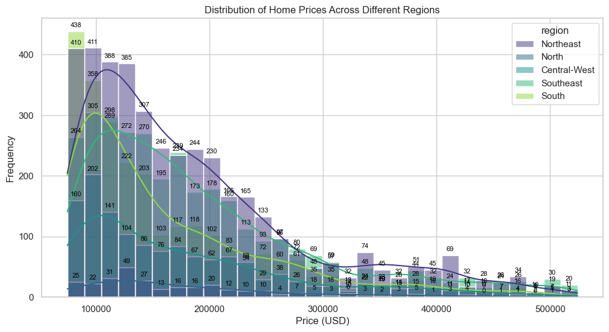

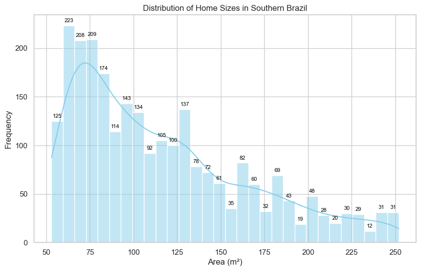

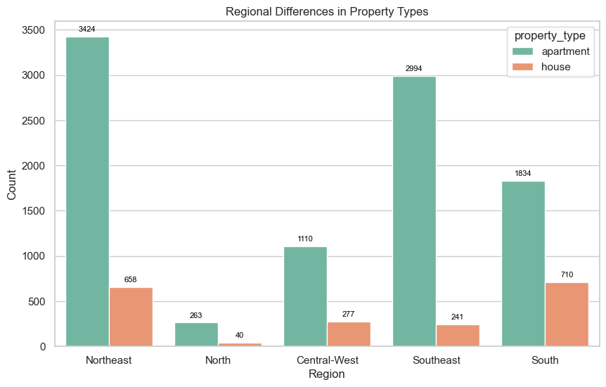

```python
import matplotlib.pyplot as plt
import seaborn as sns

# Setting the style of seaborn
sns.set(style="whitegrid")

# Distribution of home prices across different regions
plt.figure(figsize=(12, 6))
ax = sns.histplot(data=df1, x='price_usd', hue='region', kde=True, bins=30, palette='viridis')
plt.title('Distribution of Home Prices Across Different Regions')
plt.xlabel('Price (USD)')
plt.ylabel('Frequency')

# Add values on top of the bars
for p in ax.patches:
    ax.annotate(f'{p.get_height():.0f}', (p.get_x() + p.get_width() / 2., p.get_height()),
                ha='center', va='baseline', fontsize=8, color='black', xytext=(0, 5),
                textcoords='offset points')

plt.show()

# Distribution of home sizes in southern Brazil
plt.figure(figsize=(10, 6))
ax = sns.histplot(data=df1[df1['region'] == 'South'], x='area_m2', kde=True, bins=30, color='skyblue')
plt.title('Distribution of Home Sizes in Southern Brazil')
plt.xlabel('Area (m²)')
plt.ylabel('Frequency')

# Add values on top of the bars
for p in ax.patches:
    ax.annotate(f'{p.get_height():.0f}', (p.get_x() + p.get_width() / 2., p.get_height()),
                ha='center', va='baseline', fontsize=8, color='black', xytext=(0, 5),
                textcoords='offset points')

plt.show()

# Regional differences in property types
plt.figure(figsize=(10, 6))
ax = sns.countplot(data=df1, x='region', hue='property_type', palette='Set2')
plt.title('Regional Differences in Property Types')
plt.xlabel('Region')
plt.ylabel('Count')

# Add values on top of the bars
for p in ax.patches:
    ax.annotate(f'{p.get_height():.0f}', (p.get_x() + p.get_width() / 2., p.get_height()),
                ha='center', va='baseline', fontsize=8, color='black', xytext=(0, 5),
                textcoords='offset points')

plt.show()
```

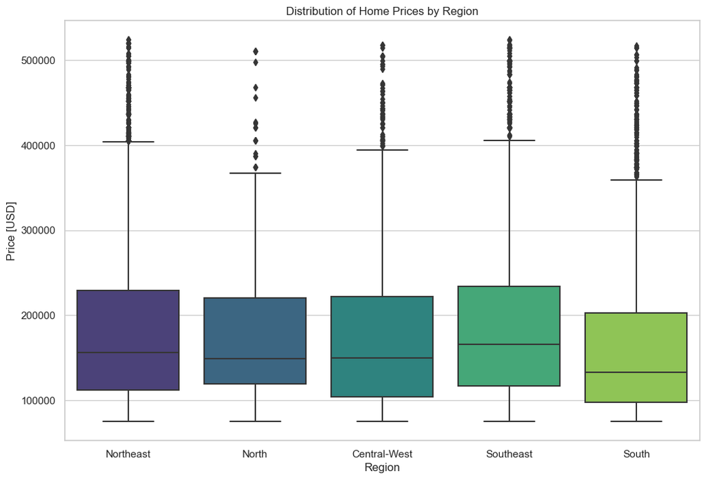

```python
import matplotlib.pyplot as plt
import seaborn as sns  # Make sure seaborn is installed: pip install seaborn
import pandas as pd

# Assuming df is your DataFrame with the relevant columns
# Modify the column names as needed based on your actual DataFrame

# Create a boxplot
plt.figure(figsize=(12, 8))
sns.boxplot(x='region', y='price_usd', data=df1, palette='viridis')

plt.title('Distribution of Home Prices by Region')
plt.xlabel('Region')
plt.ylabel('Price [USD]')
plt.show()
```

```python
#import matplotlib.pyplot as plt
#import pandas as pd

# Bar plot for total home prices across regions
#total_price_by_region = df1.groupby('state')['price_usd'].sum().sort_values()
#total_price_by_region.plot(kind='bar', figsize=(10, 6), color='skyblue')
#plt.title('Total Home Prices by Region')
#plt.xlabel('Region')
#plt.ylabel('Total Price [USD]')
#plt.show()

# Histogram for the distribution of prices within a specific region (e.g., 'South')
#south_region_prices = df1[df1['region'] == 'South']['price_usd']
#plt.figure(figsize=(10, 6))
#plt.hist(south_region_prices, bins=20, color='salmon', edgecolor='black')
#plt.title('Distribution of Home Prices in the South Region')
#plt.xlabel('Price [USD]')
#plt.ylabel('Frequency')
#plt.show()
```

# EXTRA INSIGHT ENDS HERE

Task 1.7: Give a short report on the data you now have.

The data is well-structured and ready for analysis. It includes information about different properties, their types, locations,

sizes, and prices across various regions and states. with such well structured data, we can now proceed with any further analysis or

visualization based on your objectives.From the summary statistics for the columns 'area_m2', 'price_usd', 'lat', and 'lon',

There are 11,551 entries in the dataset for each of the mentioned columns. This indicates the number of non-missing (non-null) values in each column.

The minimum values in the dataset are 53 for 'area_m2', $74,892.34 for 'price_usd', -29.995461 for 'lat', and -60.057747 for 'lon'. These are the smallest values observed in each column.

The maximum values in the dataset are 252 for 'area_m2', $524,246.39 for 'price_usd', 0.020423 for 'lat', and -34.804455 for 'lon'. These are the largest values observed in each column.

The mean (average) value for 'area_m2' is approximately 116.70 square meters, for 'price_usd' it's approximately $181,843.22, for 'lat' it's approximately -16.18, and for 'lon' it's approximately -43.94. These values represent the central tendency of each column's data.

The standard deviation measures the amount of variation or dispersion in each column. For 'area_m2', it's approximately 48.19 square meters; for 'price_usd', it's approximately $96,603.99; for 'lat', it's approximately 7.25; and for 'lon', it's approximately 5.00.

The 25% of the data falls below these values. For example, 25% of the 'area_m2' values are below 78 square meters, 25% of 'price_usd' values are below $109,217.99, 25% of 'lat' values are below -20.37, and 25% of 'lon' values are below -49.24.

The 50% of the data falls below these values. For example, 50% of 'area_m2' values are below 105 square meters, 50% of 'price_usd' values are below $152,905.19, 50% of 'lat' values are below -18.91, and 50% of 'lon' values are below -43.94.

The 75% of the data falls below these values. For example, 75% of 'area_m2' values are below 145 square meters, 75% of 'price_usd' values are below $224,677.02, 75% of 'lat' values are below -12.97, and 75% of 'lon' values are below -38.51.

#### TASK 2: DATA CLEANING of `brasil-real-estate-2.csv` raw data.

Task 2.1: Import the CSV file `brasil-real-estate-2.csv` into the DataFrame `df2`

```python
# Reading the dataset
df2 = pd.read_csv(r"C:\Users\USER\Downloads\GSRA DS Interview project\GSRA DS project\brasil-real-estate-2.csv")
# Setting the index to start from 1
df2.index = df2.index + 1
```

Task 2.2: Before you jump to the next task, look at `df2` using the `info` and `head` methods. What issues do you see in the data? How is it similar or different from `df1`?

```python
df2.head()
```

|  | property_type | state | region | lat | lon | area_m2 | price_brl |
| --- | --- | --- | --- | --- | --- | --- | --- |
| 1 | apartment | Pernambuco | Northeast | -8.134204 | -34.906326 | 72.0 | 414222.98 |
| 2 | apartment | Pernambuco | Northeast | -8.126664 | -34.903924 | 136.0 | 848408.53 |
| 3 | apartment | Pernambuco | Northeast | -8.125550 | -34.907601 | 75.0 | 299438.28 |
| 4 | apartment | Pernambuco | Northeast | -8.120249 | -34.895920 | 187.0 | 848408.53 |
| 5 | apartment | Pernambuco | Northeast | -8.142666 | -34.906906 | 80.0 | 464129.36 |

```python
df2.info()
```

```
<class 'pandas.core.frame.DataFrame'>
RangeIndex: 12833 entries, 1 to 12833
Data columns (total 7 columns):
 #   Column         Non-Null Count  Dtype
---  ------         --------------  -----
 0   property_type  12833 non-null  object
 1   state          12833 non-null  object
 2   region         12833 non-null  object
 3   lat            12833 non-null  float64
 4   lon            12833 non-null  float64
 5   area_m2        11293 non-null  float64
 6   price_brl      12833 non-null  float64
dtypes: float64(4), object(3)
memory usage: 701.9+ KB
```

```python
# Print the count of NaN values in each column
print(df2.isnull().sum())
```

```
property_type       0
state               0
region              0
lat                 0
lon                 0
area_m2          1540
price_brl           0
dtype: int64
```

### Issue

#### There seemes to be irregularities in the data size indicating the presence of null values which can be seen using the df2.isnull.sum() and also fixed using df2.dropna()

Task 2.3: Use the `price_brl` column to create a new column named `price_usd`. (Keep in mind that, when this data was collected in 2015 and 2016, a US dollar cost 3.19 Brazilian reals.)

```python
df2['price_usd'] = df2['price_brl']/3.19
## Dividing the price_brl by the dollar equivalence of 3.19 would convert the dataset to dollar
```

```python
df2
```

|  | property_type | state | region | lat | lon | area_m2 | price_brl | price_usd |
| --- | --- | --- | --- | --- | --- | --- | --- | --- |
| 1 | apartment | Pernambuco | Northeast | -8.134204 | -34.906326 | 72.0 | 414222.98 | 129850.463950 |
| 2 | apartment | Pernambuco | Northeast | -8.126664 | -34.903924 | 136.0 | 848408.53 | 265958.786834 |
| 3 | apartment | Pernambuco | Northeast | -8.125550 | -34.907601 | 75.0 | 299438.28 | 93867.799373 |
| 4 | apartment | Pernambuco | Northeast | -8.120249 | -34.895920 | 187.0 | 848408.53 | 265958.786834 |
| 5 | apartment | Pernambuco | Northeast | -8.142666 | -34.906906 | 80.0 | 464129.36 | 145495.097179 |
| ... | ... | ... | ... | ... | ... | ... | ... | ... |
| 12829 | house | São Paulo | Southeast | -23.587495 | -46.559401 | 250.0 | 429194.89 | 134543.852665 |
| 12830 | apartment | São Paulo | Southeast | -23.522029 | -46.189290 | 55.0 | 252398.80 | 79121.880878 |
| 12831 | apartment | São Paulo | Southeast | -23.526443 | -46.529182 | 57.0 | 319400.84 | 100125.655172 |
| 12832 | house | Tocantins | North | -8.848399 | -48.511164 | NaN | 529007.65 | 165833.119122 |
| 12833 | apartment | Tocantins | North | -10.249091 | -48.324286 | 70.0 | 289457.01 | 90738.874608 |

12833 rows × 8 columns

Task 2.4: Drop the `"price_brl"` column from `df2`, as well as any rows that have `NaN` values.

```python
# dropping the NaN values
df2 = df2.dropna()
```

```python
# Droping the specified columns
df2 = df2.drop(['price_brl'], axis=1)
```

```python
# Print the count of NaN values in each column
print(df2.isnull().sum())
```

```
property_type    0
state            0
region           0
lat              0
lon              0
area_m2          0
price_usd        0
dtype: int64
```

```python
df2.info()
```

```
<class 'pandas.core.frame.DataFrame'>
Int64Index: 11293 entries, 1 to 12833
Data columns (total 7 columns):
 #   Column         Non-Null Count  Dtype
---  ------         --------------  -----
 0   property_type  11293 non-null  object
 1   state          11293 non-null  object
 2   region         11293 non-null  object
 3   lat            11293 non-null  float64
 4   lon            11293 non-null  float64
 5   area_m2        11293 non-null  float64
 6   price_usd      11293 non-null  float64
dtypes: float64(4), object(3)
memory usage: 705.8+ KB
```

```python
df2.head(3)
```

|  | property_type | state | region | lat | lon | area_m2 | price_usd |
| --- | --- | --- | --- | --- | --- | --- | --- |
| 1 | apartment | Pernambuco | Northeast | -8.134204 | -34.906326 | 72.0 | 129850.463950 |
| 2 | apartment | Pernambuco | Northeast | -8.126664 | -34.903924 | 136.0 | 265958.786834 |
| 3 | apartment | Pernambuco | Northeast | -8.125550 | -34.907601 | 75.0 | 93867.799373 |

```python
# Assuming your DataFrame is named df
#df2.to_csv('df2.csv', index=False)
```

Task 2.5: Concatenate `df1` and `df2` to create a new DataFrame named `df`.

```python
frames = [df1, df2]

# concatenate along rows, we use axis=0
df = pd.concat(frames, axis=0, ignore_index=False)

# Display the result
df
```

|  | property_type | region | area_m2 | price_usd | lat | lon | state |
| --- | --- | --- | --- | --- | --- | --- | --- |
| 1 | apartment | Northeast | 110.0 | 187230.850000 | -9.644305 | -35.708814 | Alagoas |
| 2 | apartment | Northeast | 65.0 | 81133.370000 | -9.643093 | -35.704840 | Alagoas |
| 3 | house | Northeast | 211.0 | 154465.450000 | -9.622703 | -35.729795 | Alagoas |
| 4 | apartment | Northeast | 99.0 | 146013.200000 | -9.622837 | -35.719556 | Alagoas |
| 5 | apartment | Northeast | 55.0 | 101416.710000 | -9.654955 | -35.700227 | Alagoas |
| ... | ... | ... | ... | ... | ... | ... | ... |
| 12828 | house | Southeast | 180.0 | 131414.921630 | -23.595098 | -46.796448 | São Paulo |
| 12829 | house | Southeast | 250.0 | 134543.852665 | -23.587495 | -46.559401 | São Paulo |
| 12830 | apartment | Southeast | 55.0 | 79121.880878 | -23.522029 | -46.189290 | São Paulo |
| 12831 | apartment | Southeast | 57.0 | 100125.655172 | -23.526443 | -46.529182 | São Paulo |
| 12833 | apartment | North | 70.0 | 90738.874608 | -10.249091 | -48.324286 | Tocantins |

22844 rows × 7 columns

```python
# Assuming your DataFrame is named df
#df.to_csv('df.csv', index=False)
```

### TASK 3: EXPLORATION

In this section, you'll use your new data visualization skills to learn more about the regional differences in the Brazilian real estate market.

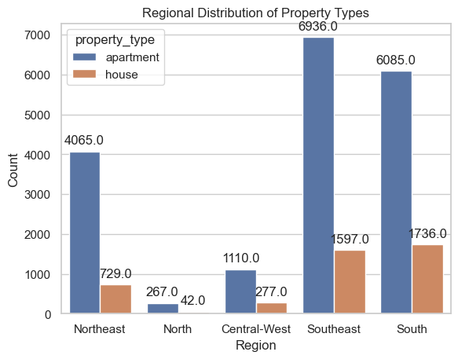

```python
import seaborn as sns
import matplotlib.pyplot as plt

ax = sns.countplot(x='region', hue='property_type', data=df)
plt.title('Regional Distribution of Property Types')
plt.xlabel('Region')
plt.ylabel('Count')

# Adding value annotations
for p in ax.patches:
    ax.annotate(f'{p.get_height()}', (p.get_x() + p.get_width() / 2., p.get_height()),
                ha='center', va='center', xytext=(0, 10), textcoords='offset points')

plt.show()
```

TASK 3.1: Use the `describe` method to create a DataFrame `summary_stats` with the summary statistics for the `"area_m2"` and `"price_usd"` columns.

```python
summary_stats = df1[['area_m2', 'price_usd']].describe()

# If you want to transpose the result for better readability
summary_stats = summary_stats.transpose()

# Display the summary statistics DataFrame
summary_stats
```

|  | count | mean | std | min | 25% | 50% | 75% | max |
| --- | --- | --- | --- | --- | --- | --- | --- | --- |
| area_m2 | 11551.0 | 116.695264 | 48.186630 | 53.00 | 78.00 | 105.00 | 145.00 | 252.00 |
| price_usd | 11551.0 | 181843.221930 | 96603.990393 | 74892.34 | 109217.99 | 152905.19 | 224677.02 | 524246.39 |

TASK 3.2: Create a histogram of `"price_usd"`. Make sure that the x-axis has the label `"Price [USD]"`, the y-axis has the label `"Frequency"`, and the plot has the title `"Distribution of Home Prices"`.

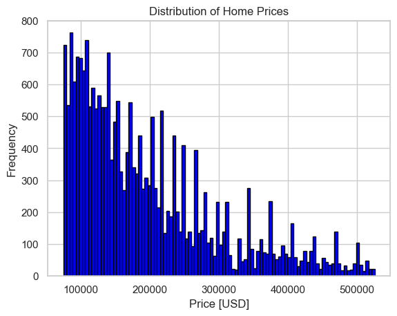

```python
import matplotlib.pyplot as plt

plt.hist(df['price_usd'], bins=100, color='blue', edgecolor='black')

# Adding labels and title
plt.title('Distribution of Home Prices')
plt.xlabel('Price [USD]')
plt.ylabel('Frequency')

# Display the histogram
plt.show()
```

TASK 3.3: Create a horizontal boxplot of `"area_m2"`. Make sure that the x-axis has the label `"Area [sq meters]"` and the plot has the title `"Distribution of Home Sizes"`.

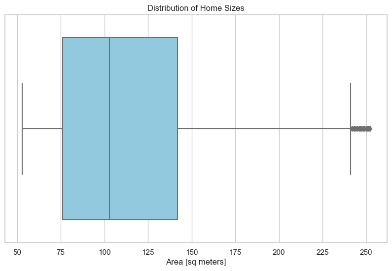

```python
import matplotlib.pyplot as plt
import seaborn as sns  # Make sure seaborn is installed

# Set the style for better aesthetics
sns.set(style="whitegrid")

# Create a horizontal boxplot
plt.figure(figsize=(10, 6))  # Adjust the figure size as needed
sns.boxplot(x='area_m2', data=df, orient='h', color='skyblue')
plt.title('Distribution of Home Sizes')
plt.xlabel('Area [sq meters]')
plt.show()
```

TASK 3.4: Use the `groupby` method to create a Series named `mean_price_by_region` that shows the mean home price in each region in Brazil, sorted from smallest to largest.

```python
mean_price_by_region = df.groupby('region')['price_usd'].mean().sort_values()

# Display the resulting Series
print(mean_price_by_region)
```

```
region
Central-West    178596.283663
North           181308.958207
Northeast       185422.985441
South           189012.345265
Southeast       208996.762778
Name: price_usd, dtype: float64
```

TASK 3.5: Use `mean_price_by_region` to create a bar chart. Make sure you label the x-axis as `"Region"` and the y-axis as `"Mean Price [USD]"` and give the chart the title `"Mean Home Price by Region"`.

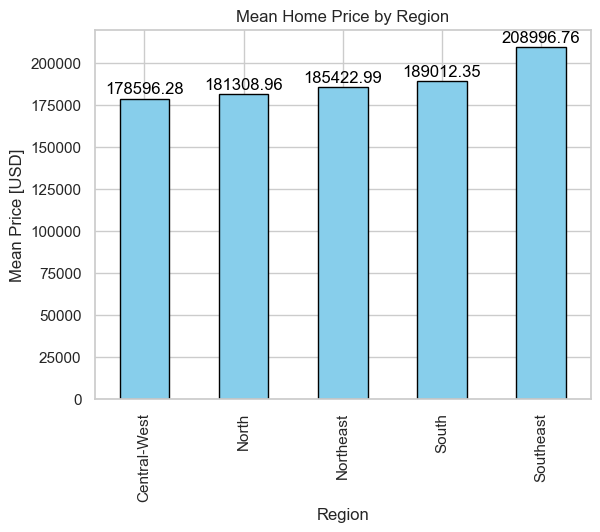

```python
import matplotlib.pyplot as plt

# Assuming mean_price_by_region is the Series you created
ax = mean_price_by_region.plot(kind='bar', color='skyblue', edgecolor='black')

# Adding labels and title
plt.xlabel('Region')
plt.ylabel('Mean Price [USD]')
plt.title('Mean Home Price by Region')

# Adding values on top of the bars
for i, v in enumerate(mean_price_by_region):
    ax.text(i, v + 1000, f'{v:.2f}', color='black', ha='center', va='bottom')

# Display the plot
plt.show()
```

You're now going to shift your focus to the southern region of Brazil and look at the relationship between home size and price.

TASK 3.7: Create a DataFrame `df_south` that contains all the homes from `df` that are in the `"South"` region.

```python
df_south = df[df['region'] == 'South']
df_south
```

|  | property_type | region | area_m2 | price_usd | lat | lon | state |
| --- | --- | --- | --- | --- | --- | --- | --- |
| 9305 | apartment | South | 127.0 | 296448.850000 | -25.455704 | -49.292918 | Paraná |
| 9306 | apartment | South | 104.0 | 219996.250000 | -25.455704 | -49.292918 | Paraná |
| 9307 | apartment | South | 100.0 | 194210.500000 | -25.460236 | -49.293812 | Paraná |
| 9308 | apartment | South | 77.0 | 149252.940000 | -25.460236 | -49.293812 | Paraná |
| 9309 | apartment | South | 73.0 | 144167.750000 | -25.460236 | -49.293812 | Paraná |
| ... | ... | ... | ... | ... | ... | ... | ... |
| 9742 | apartment | South | 117.0 | 309763.761755 | -26.966631 | -48.636383 | Santa Catarina |
| 9743 | house | South | 110.0 | 88616.510972 | -26.754795 | -48.729183 | Santa Catarina |
| 9745 | house | South | 165.0 | 110770.645768 | -27.454047 | -48.411582 | Santa Catarina |
| 9746 | apartment | South | 65.0 | 86045.485893 | -26.997210 | -48.633877 | Santa Catarina |
| 9748 | apartment | South | 79.0 | 238122.915361 | -27.594744 | -48.541233 | Santa Catarina |

7821 rows × 7 columns

TASK 3.8: Use the `value_counts` method to create a Series `homes_by_state` that contains the number of properties in each state in `df_south`.

```python
homes_by_state = df_south['state'].value_counts()
homes_by_state
```

```
Rio Grande do Sul    2643
Santa Catarina       2634
Paraná               2544
Name: state, dtype: int64
```

TASK 3.9: Create a scatter plot showing price vs. area for the state in `df_south` that has the largest number of properties. Be sure to label the x-axis `"Area [sq meters]"` and the y-axis `"Price [USD]"`; and use the title `"<name of state>: Price vs. Area"`

```python
import matplotlib.pyplot as plt

# Finding the state with the largest number of properties in df_south
largest_state = homes_by_state.idxmax()
largest_state
```

```
'Rio Grande do Sul'
```

```python
# Filtering df_south for the largest state
df_largest_state = df_south[df_south['state'] == largest_state]
largest_state
```

```
'Rio Grande do Sul'
```

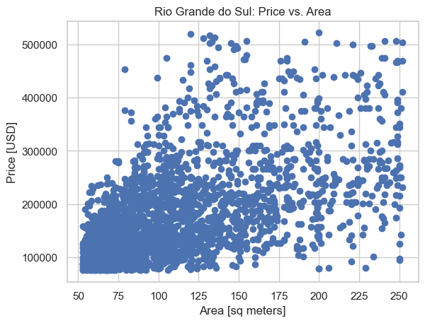

```python
# Creating a scatter plot
plt.scatter(df_largest_state['area_m2'], df_largest_state['price_usd'])
plt.title(f'{largest_state}: Price vs. Area')
plt.xlabel('Area [sq meters]')
plt.ylabel('Price [USD]')
plt.show()
```

TASK 3.9.1: Create a dictionary `south_states_corr`, where the keys are the names of the three states in the `"South"` region of Brazil, and their associated values are the correlation coefficient between `"area_m2"` and `"price_usd"` in that state.

As an example, here's a dictionary with the states and correlation coefficients for the Southeast region. Since you're looking at a different region, the states and coefficients will be different, but the structure of the dictionary will be the same.

```
{'Espírito Santo': 0.6311332554173303,
 'Minas Gerais': 0.5830029036378931,
 'Rio de Janeiro': 0.4554077103515366,
 'São Paulo': 0.45882050624839366}
```

```python
south_states_corr = {}

# Iterating over the unique states in the "South" region
for state in df_south['state'].unique():
    # Filtering the DataFrame for the current state
    state_data = df_south[df_south['state'] == state]

    # Calculating the correlation coefficient between "area_m2" and "price_usd"
    correlation_coefficient = state_data['area_m2'].corr(state_data['price_usd'])

    # Adding the state and its correlation coefficient to the dictionary
    south_states_corr[state] = correlation_coefficient

# Print the resulting dictionary
south_states_corr
```

```
{'Paraná': 0.5436659935502659,
 'Rio Grande do Sul': 0.5773267433717684,
 'Santa Catarina': 0.5068121776366781}
```

```python
south_states_corr
```

```
{'Paraná': 0.5436659935502659,
 'Rio Grande do Sul': 0.5773267433717684,
 'Santa Catarina': 0.5068121776366781}
```